# Data Analysis and Statistical Inference Lab 7

LKB

# Lectures

Testing the weight of the books

```r
library(DAAG)
data(allbacks)

#fit model

book_mlr = lm(weight ~ volume + cover, data = allbacks)
summary(book_mlr)
```

```
##
## Call:
## lm(formula = weight ~ volume + cover, data = allbacks)
##
## Residuals:
##     Min      1Q  Median      3Q     Max
## -110.10  -32.32  -16.10   28.93  210.95
##
## Coefficients:
##               Estimate Std. Error t value Pr(>|t|)
## (Intercept)  197.96284   59.19274   3.344 0.005841 **
## volume         0.71795    0.06153  11.669  6.6e-08 ***
## coverpb     -184.04727   40.49420  -4.545 0.000672 ***
## ---
## Signif. codes:  0 '***' 0.001 '**' 0.01 '*' 0.05 '.' 0.1 ' ' 1
##
## Residual standard error: 78.2 on 12 degrees of freedom
## Multiple R-squared:  0.9275, Adjusted R-squared:  0.9154
## F-statistic: 76.73 on 2 and 12 DF,  p-value: 1.455e-07
```

## R^2 adjusted

Lts first consider single variable model

```r
states = read.csv("http://d396qusza40orc.cloudfront.net/statistics/lec_resources/states.csv")
pov_slr = lm(poverty ~ female_house, data = states )
summary(pov_slr)
```

```
##
## Call:
## lm(formula = poverty ~ female_house, data = states)
##
## Residuals:
##     Min      1Q  Median      3Q     Max
## -5.7537 -1.8252 -0.0375  1.5565  6.3285
##
## Coefficients:
##              Estimate Std. Error t value Pr(>|t|)
## (Intercept)    3.3094     1.8970   1.745   0.0873 .
## female_house   0.6911     0.1599   4.322 7.53e-05 ***
## ---
## Signif. codes:  0 '***' 0.001 '**' 0.01 '*' 0.05 '.' 0.1 ' ' 1
##
## Residual standard error: 2.664 on 49 degrees of freedom
## Multiple R-squared:  0.276,  Adjusted R-squared:  0.2613
## F-statistic: 18.68 on 1 and 49 DF,  p-value: 7.534e-05
```

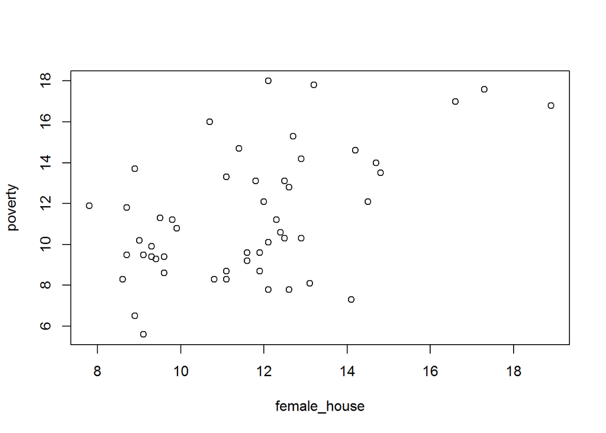

```r
plot(poverty ~ female_house, data = states )
```

Notice that % of variability not explained is residuals as $R^2 = \frac{\text{explained variability}}{\text{total variability}}$. Lets now add more variables

```r
pov_mlr = lm(poverty ~ female_house + white, data = states )
summary(pov_mlr)
```

```
##
## Call:
## lm(formula = poverty ~ female_house + white, data = states)
##
## Residuals:
##     Min      1Q  Median      3Q     Max
## -5.5245 -1.8526 -0.0381  1.3770  6.2689
##
## Coefficients:
##              Estimate Std. Error t value Pr(>|t|)
## (Intercept)  -2.57894    5.78491  -0.446 0.657743
## female_house  0.88689    0.24191   3.666 0.000615 ***
## white         0.04418    0.04101   1.077 0.286755
## ---
## Signif. codes:  0 '***' 0.001 '**' 0.01 '*' 0.05 '.' 0.1 ' ' 1
##
## Residual standard error: 2.659 on 48 degrees of freedom
## Multiple R-squared:  0.2931, Adjusted R-squared:  0.2637
## F-statistic: 9.953 on 2 and 48 DF,  p-value: 0.0002422
```

```r
anova(pov_mlr)
```

```
## Analysis of Variance Table
##
## Response: poverty
##              Df Sum Sq Mean Sq F value    Pr(>F)
## female_house  1 132.57 132.568 18.7447 7.562e-05 ***
## white         1   8.21   8.207  1.1605    0.2868
## Residuals    48 339.47   7.072
## ---
## Signif. codes:  0 '***' 0.001 '**' 0.01 '*' 0.05 '.' 0.1 ' ' 1
```

### Correlation of predictors

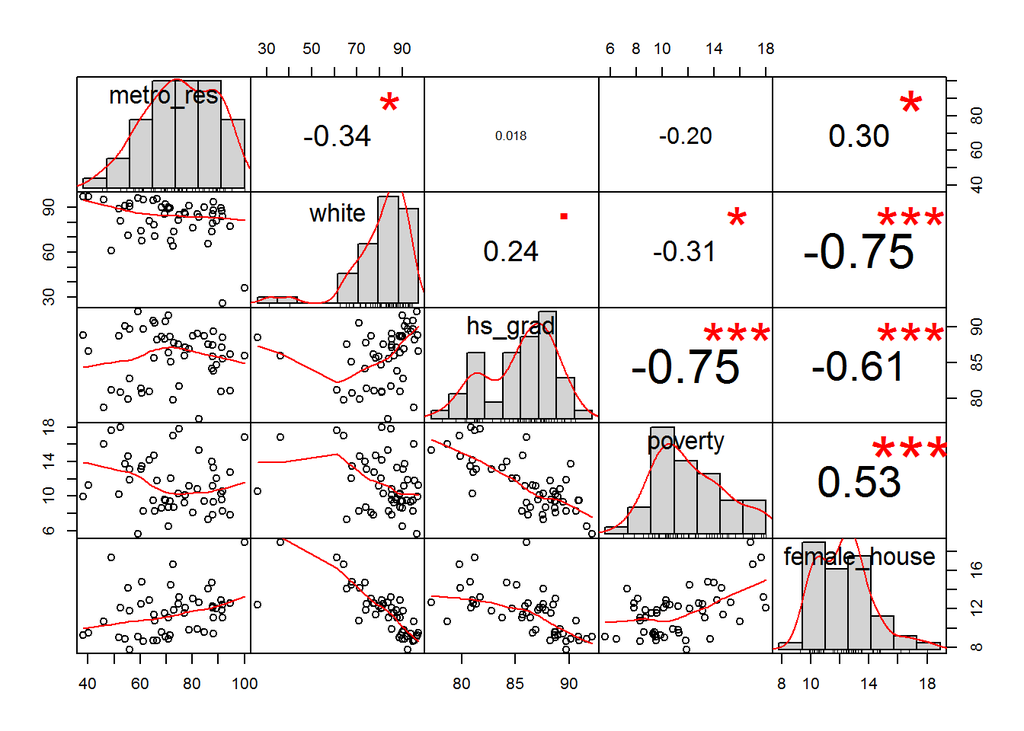

```r
require(lattice)
require(ggplot2)
library(GGally)

library(PerformanceAnalytics)
chart.Correlation(states[2:6]) #good and fast
```

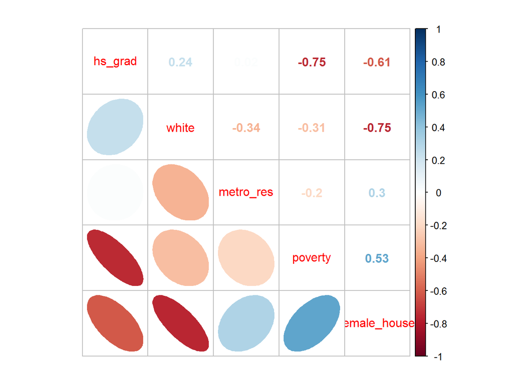

```r
#ggpairs(states[2:6]) #beautiful but dead slow


library(corrplot)

#order by FCP
corrplot.mixed(cor(states[2:6]), lower = "ellipse", upper = "number", order = "FPC")
```

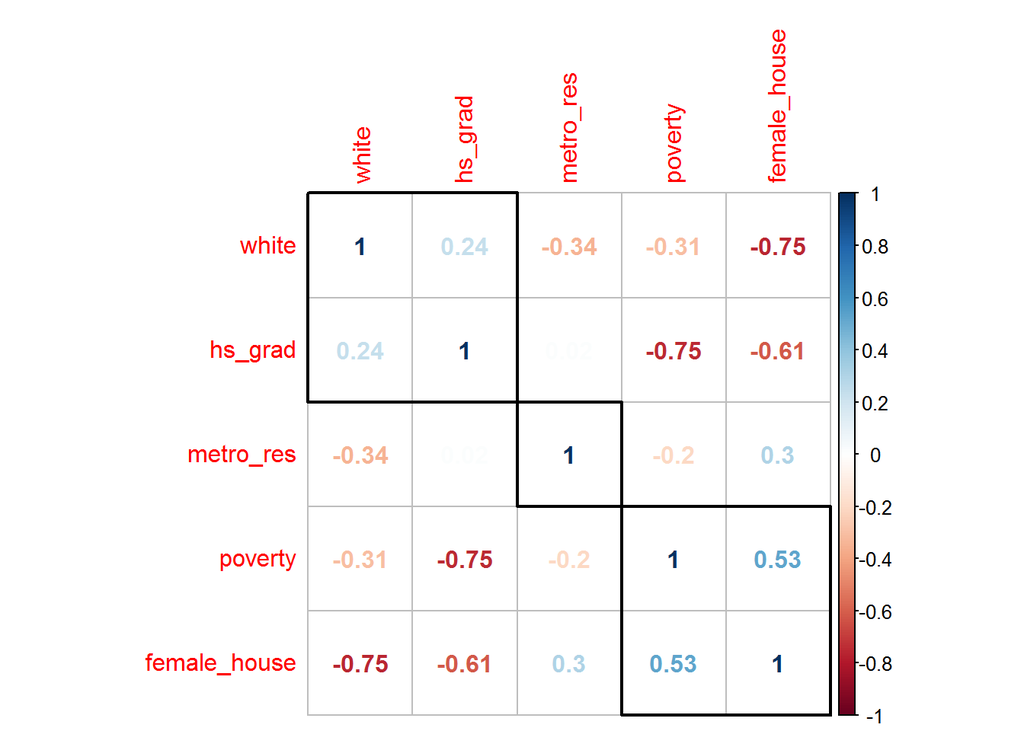

```r
#order by hierarchical clustering and then show groups
corrplot(cor(states[2:6]), method = "number", order = "hclust", addrect = 3)
```

### Inference for MLR

```r
cognitive = read.csv("http://bit.ly/dasi_cognitive")
cog_full = lm(kid_score ~ mom_hs+mom_iq+mom_work+mom_age, data = cognitive )
summary(cog_full)
```

```
##
## Call:
## lm(formula = kid_score ~ mom_hs + mom_iq + mom_work + mom_age,
##     data = cognitive)
##
## Residuals:
##     Min      1Q  Median      3Q     Max
## -54.045 -12.918   1.992  11.563  49.267
##
## Coefficients:
##             Estimate Std. Error t value Pr(>|t|)
## (Intercept) 19.59241    9.21906   2.125   0.0341 *
## mom_hsyes    5.09482    2.31450   2.201   0.0282 *
## mom_iq       0.56147    0.06064   9.259   <2e-16 ***
## mom_workyes  2.53718    2.35067   1.079   0.2810
## mom_age      0.21802    0.33074   0.659   0.5101
## ---
## Signif. codes:  0 '***' 0.001 '**' 0.01 '*' 0.05 '.' 0.1 ' ' 1
##
## Residual standard error: 18.14 on 429 degrees of freedom
## Multiple R-squared:  0.2171, Adjusted R-squared:  0.2098
## F-statistic: 29.74 on 4 and 429 DF,  p-value: < 2.2e-16
```

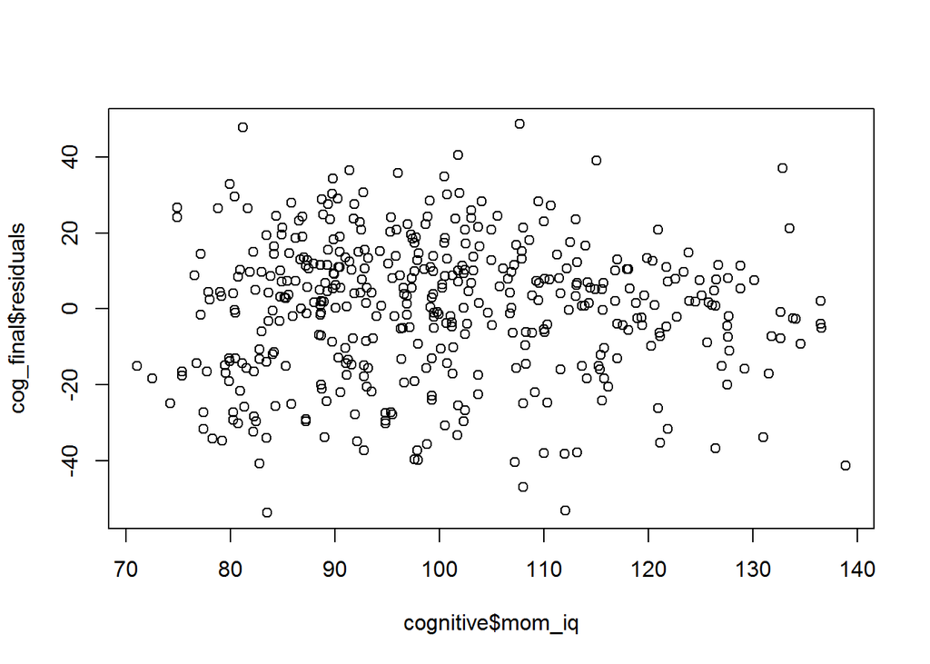

```r
cog_final = lm(kid_score ~ mom_hs+mom_iq+mom_work, data = cognitive )
#linear relationship test
plot(cog_final$residuals ~ cognitive$mom_iq) #we can only test numerical
```

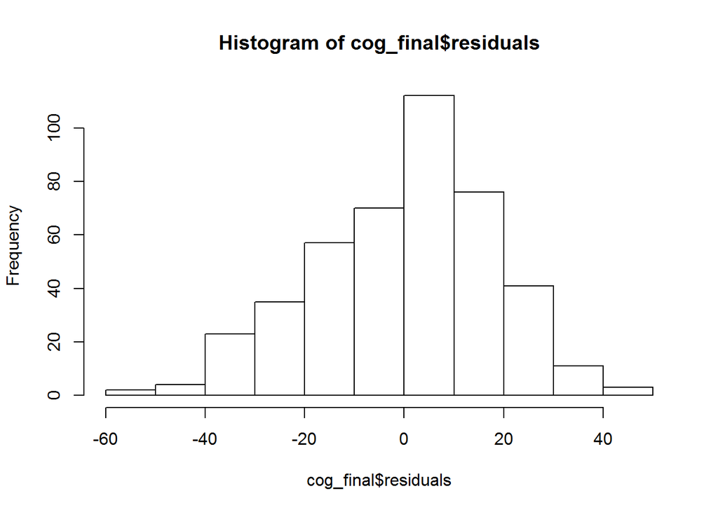

```r
hist(cog_final$residuals)
```

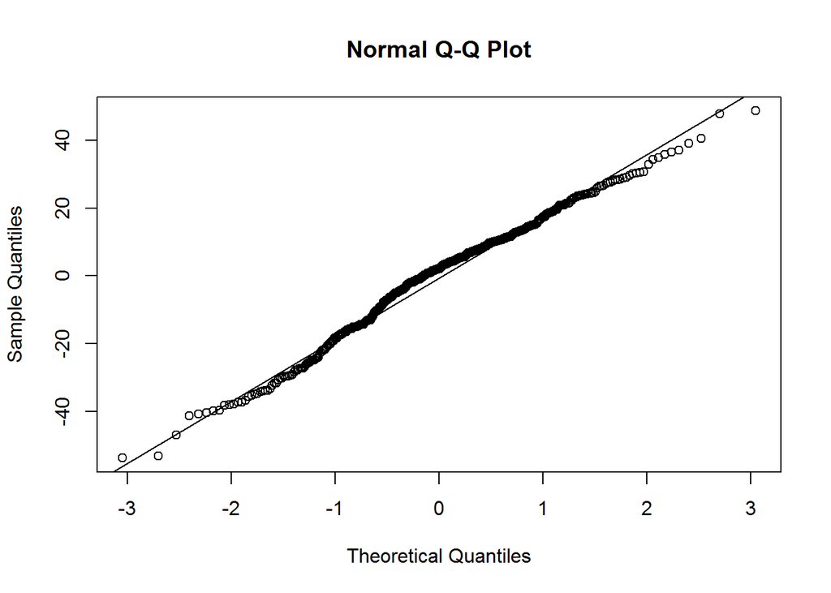

```r
qqnorm(cog_final$residuals)
qqline(cog_final$residuals)
```

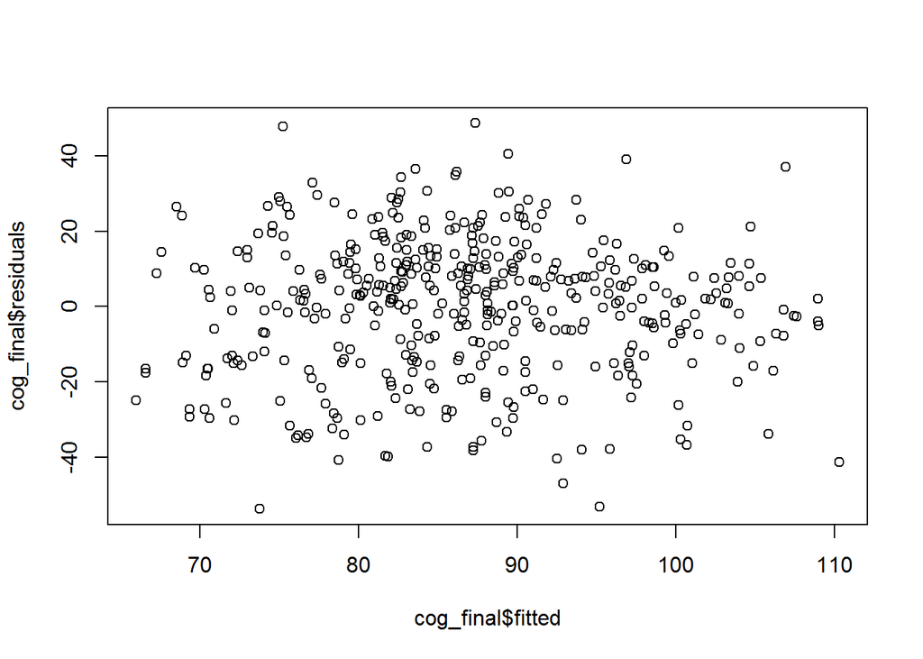

```r
#constant variability of residuals
plot(cog_final$residuals ~ cog_final$fitted)
```

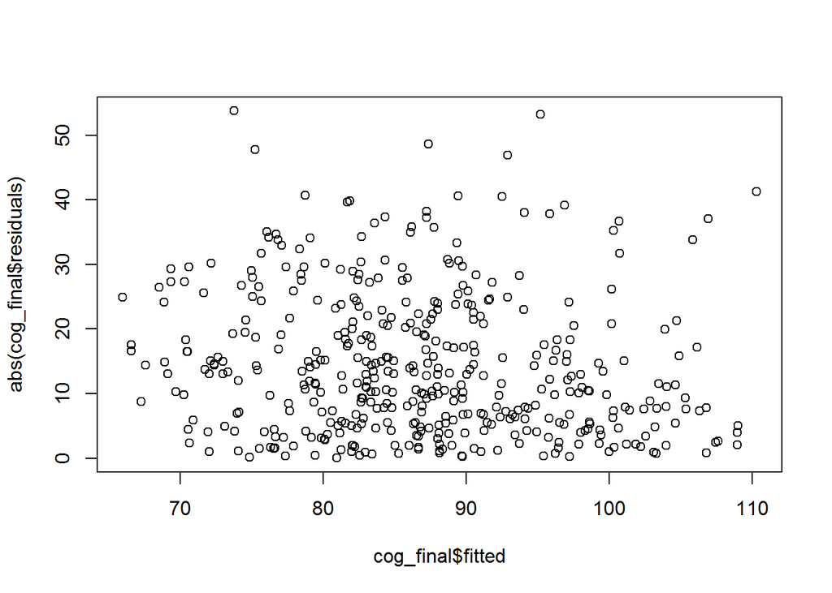

```r
plot(abs(cog_final$residuals) ~ cog_final$fitted)
```

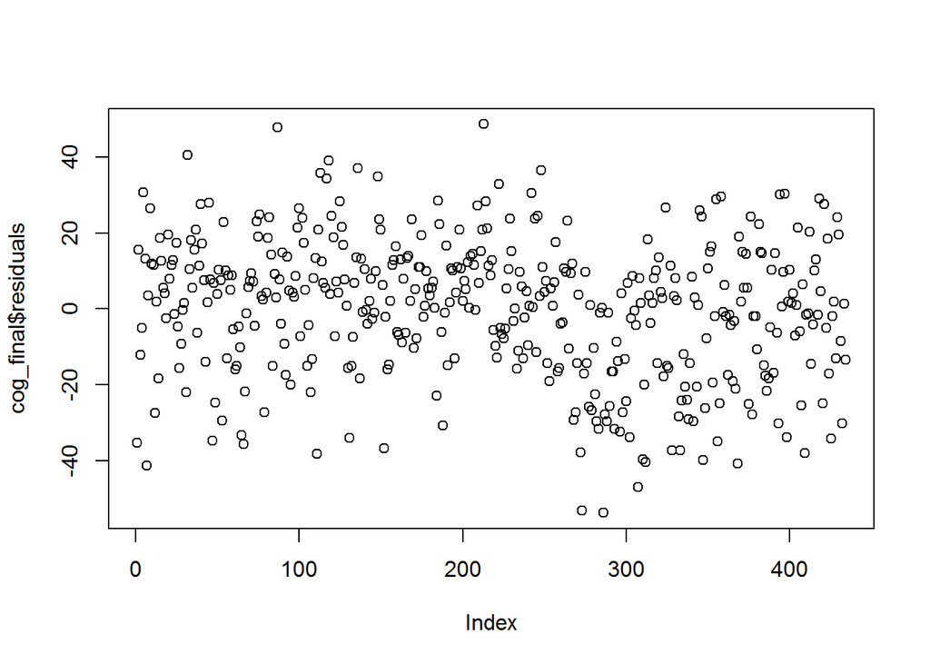

```r
#independent residuals
plot(cog_final$residuals)
```

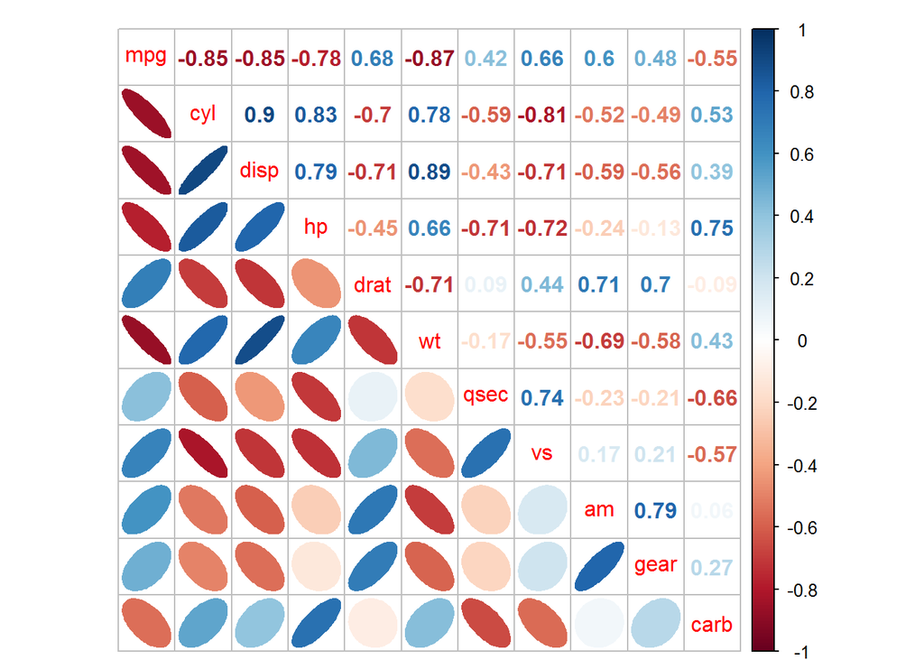

```r
#https://cran.r-project.org/web/packages/corrplot/vignettes/corrplot-intro.htm
library(corrplot)
M <- cor(mtcars)

corrplot.mixed(M, lower = "ellipse", upper = "number")
```

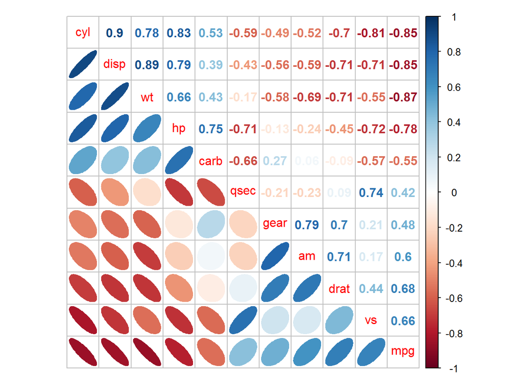

```r
corrplot.mixed(M, lower = "ellipse", upper = "number", order = "FPC")
```

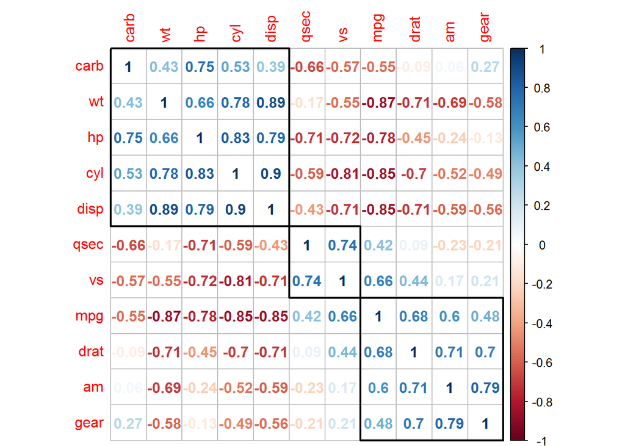

```r
corrplot(M, method = "number", order = "hclust", addrect = 3) #draw rectangles around the chart of corrrlation matrix based on the results of hierarchical clustering.
```

```r
library(PerformanceAnalytics)
#see http://www.r-bloggers.com/more-on-exploring-correlations-in-r/

## Correlation matrix with p-values.
##See http://goo.gl/nahmV for documentation of this function
cor.prob <- function (X, dfr = nrow(X) - 2) {
  R <- cor(X, use="pairwise.complete.obs")
  above <- row(R) < col(R)
  r2 <- R[above]^2
  Fstat <- r2 * dfr/(1 - r2)
  R[above] <- 1 - pf(Fstat, 1, dfr)
  R[row(R) == col(R)] <- NA
  R
}

## Use this to dump the cor.prob output to a 4 column matrix
## with row/column indices, correlation, and p-value.
## See StackOverflow question: http://goo.gl/fCUcQ
flattenSquareMatrix <- function(m) {
  if( (class(m) != "matrix") | (nrow(m) != ncol(m))) stop("Must be a square matrix.")
  if(!identical(rownames(m), colnames(m))) stop("Row and column names must be equal.")
  ut <- upper.tri(m)
  data.frame(i = rownames(m)[row(m)[ut]],
             j = rownames(m)[col(m)[ut]],
             cor=t(m)[ut],
             p=m[ut])
}

# get some data from the mtcars built-in dataset
mydata <- mtcars[, c(1,3,4,5,6)]

# correlation matrix
cor(mydata)
```

```
##             mpg       disp         hp       drat         wt
## mpg   1.0000000 -0.8475514 -0.7761684  0.6811719 -0.8676594
## disp -0.8475514  1.0000000  0.7909486 -0.7102139  0.8879799
## hp   -0.7761684  0.7909486  1.0000000 -0.4487591  0.6587479
## drat  0.6811719 -0.7102139 -0.4487591  1.0000000 -0.7124406
## wt   -0.8676594  0.8879799  0.6587479 -0.7124406  1.0000000
```

```r
# correlation matrix with p-values
cor.prob(mydata)
```

```
##             mpg          disp            hp          drat           wt
## mpg          NA  9.380327e-10  1.787835e-07  1.776240e-05 1.293958e-10
## disp -0.8475514            NA  7.142679e-08  5.282022e-06 1.222322e-11
## hp   -0.7761684  7.909486e-01            NA  9.988772e-03 4.145827e-05
## drat  0.6811719 -7.102139e-01 -4.487591e-01            NA 4.784260e-06
## wt   -0.8676594  8.879799e-01  6.587479e-01 -7.124406e-01           NA
```

```r
# "flatten" that table
flattenSquareMatrix(cor.prob(mydata))
```

```
##       i    j        cor            p
## 1   mpg disp -0.8475514 9.380327e-10
## 2   mpg   hp -0.7761684 1.787835e-07
## 3  disp   hp  0.7909486 7.142679e-08
## 4   mpg drat  0.6811719 1.776240e-05
## 5  disp drat -0.7102139 5.282022e-06
## 6    hp drat -0.4487591 9.988772e-03
## 7   mpg   wt -0.8676594 1.293958e-10
## 8  disp   wt  0.8879799 1.222322e-11
## 9    hp   wt  0.6587479 4.145827e-05
## 10 drat   wt -0.7124406 4.784260e-06
```

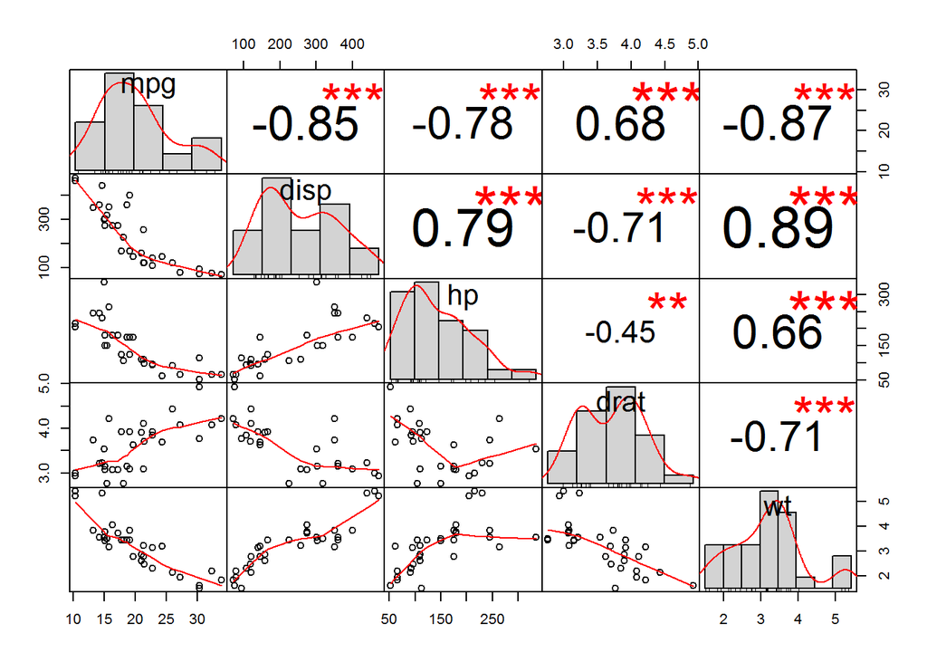

```r
# plot the data
library(PerformanceAnalytics)
chart.Correlation(mydata)
```

# Lab 7: Multiple linear regression

Many college courses conclude by giving students the opportunity to evaluate the course and the instructor anonymously. However, the use of these student evaluations as an indicator of course quality and teaching effectiveness is often criticized because these measures may reflect the influence of non-teaching related characteristics, such as the physical appearance of the instructor.

In this lab we will analyze the data from this study in order to learn what goes into a positive professor evaluation.

## The data

```r
rm(list=ls(all=TRUE))
load(url("http://www.openintro.org/stat/data/evals.RData"))

summary(evals$score)
```

```
##    Min. 1st Qu.  Median    Mean 3rd Qu.    Max.
##   2.300   3.800   4.300   4.175   4.600   5.000
```

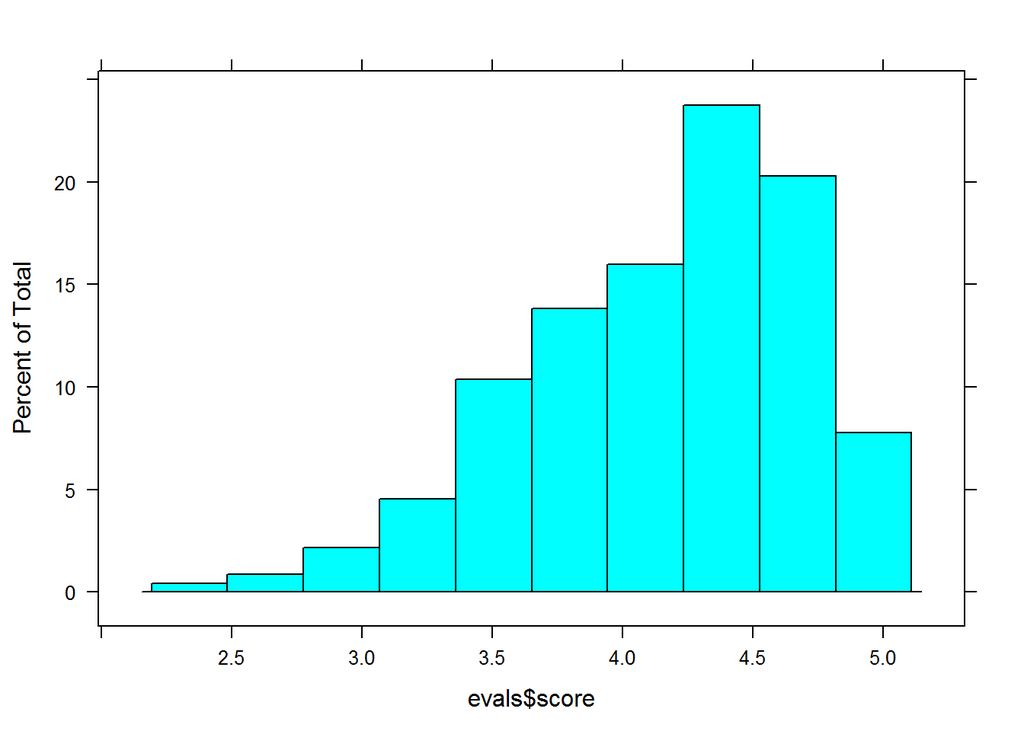

```r
histogram(evals$score)
```

Select two other variables and describe their relationship using an appropriate visualization (scatterplot, side-by-side boxplots, or mosaic plot).

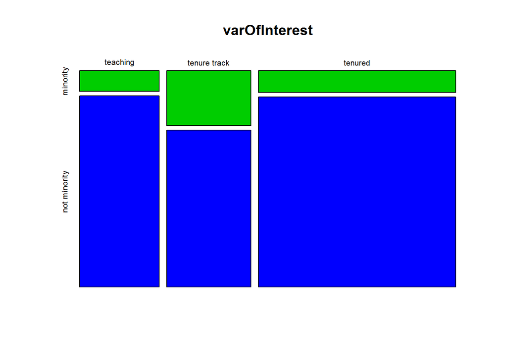

```r
varOfInterest = table(evals$rank,evals$ethnicity)
mosaicplot(varOfInterest, color = 3:4)
```

## Simple linear regression

The fundamental phenomenon suggested by the study is that better looking teachers are evaluated more favorably.

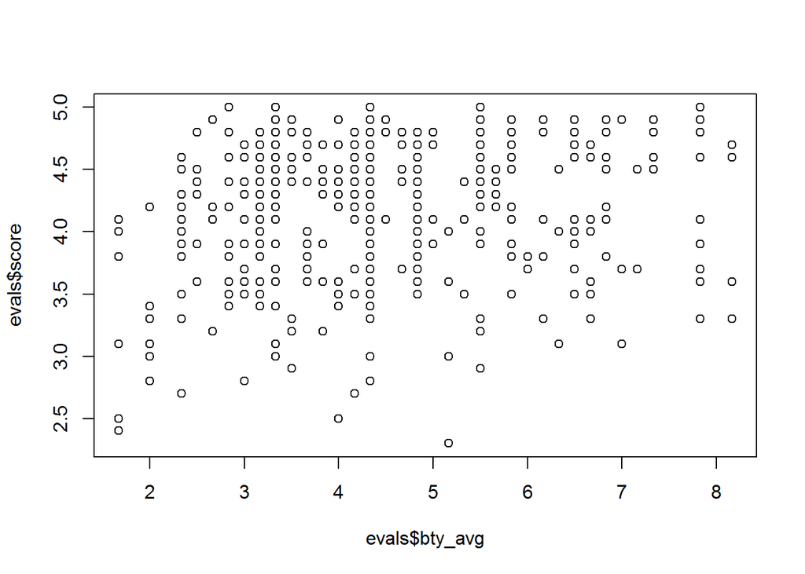

```r
plot(evals$score ~ evals$bty_avg)
```

```r
#add a bit of nose so we can see all the points
plot(jitter(evals$score) ~ jitter(evals$bty_avg))

m_bty = lm(evals$score ~ evals$bty_avg)
summary(m_bty)
```

```
##
## Call:
## lm(formula = evals$score ~ evals$bty_avg)
##
## Residuals:
##     Min      1Q  Median      3Q     Max
## -1.9246 -0.3690  0.1420  0.3977  0.9309
##
## Coefficients:
##               Estimate Std. Error t value Pr(>|t|)
## (Intercept)    3.88034    0.07614   50.96  < 2e-16 ***
## evals$bty_avg  0.06664    0.01629    4.09 5.08e-05 ***
## ---
## Signif. codes:  0 '***' 0.001 '**' 0.01 '*' 0.05 '.' 0.1 ' ' 1
##
## Residual standard error: 0.5348 on 461 degrees of freedom
## Multiple R-squared:  0.03502,    Adjusted R-squared:  0.03293
## F-statistic: 16.73 on 1 and 461 DF,  p-value: 5.083e-05
```

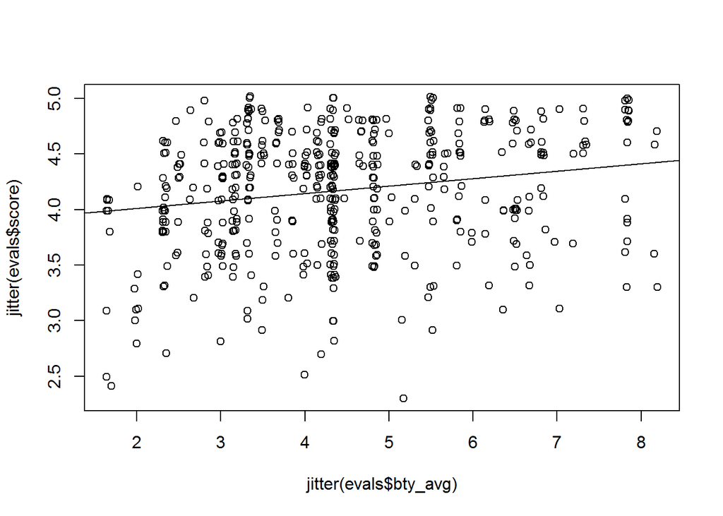

```r
abline(m_bty)
```

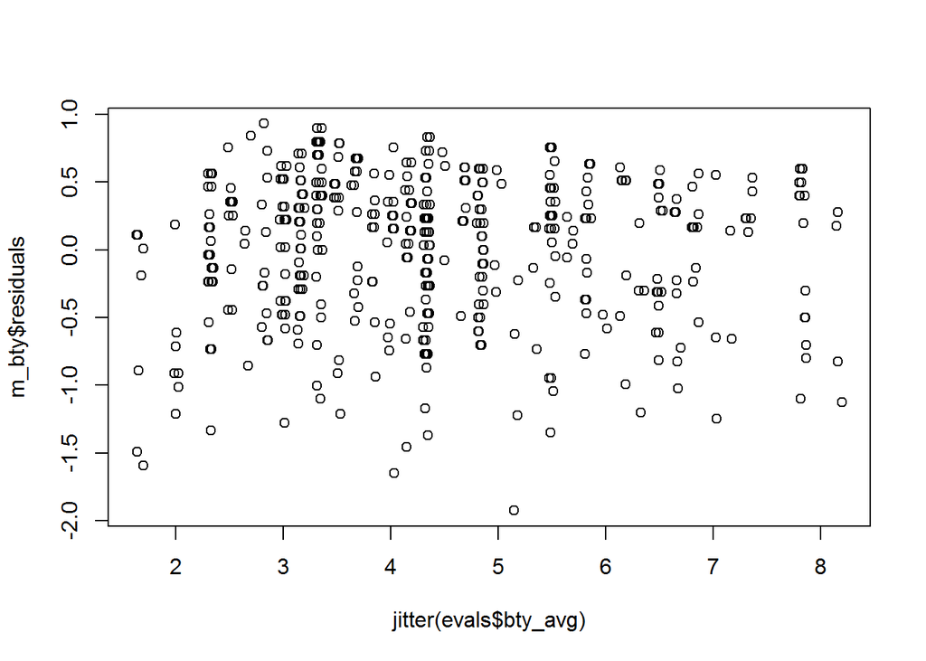

```r
#linear relationship test
plot(m_bty$residuals~ jitter(evals$bty_avg))
```

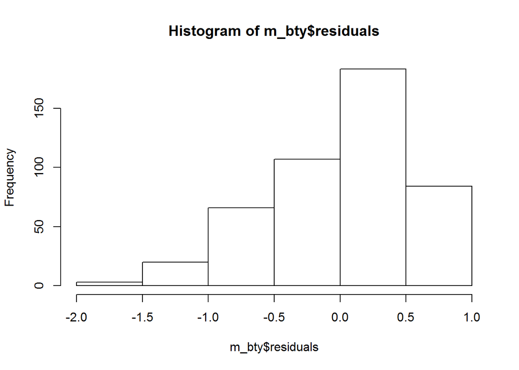

```r
hist(m_bty$residuals)
```

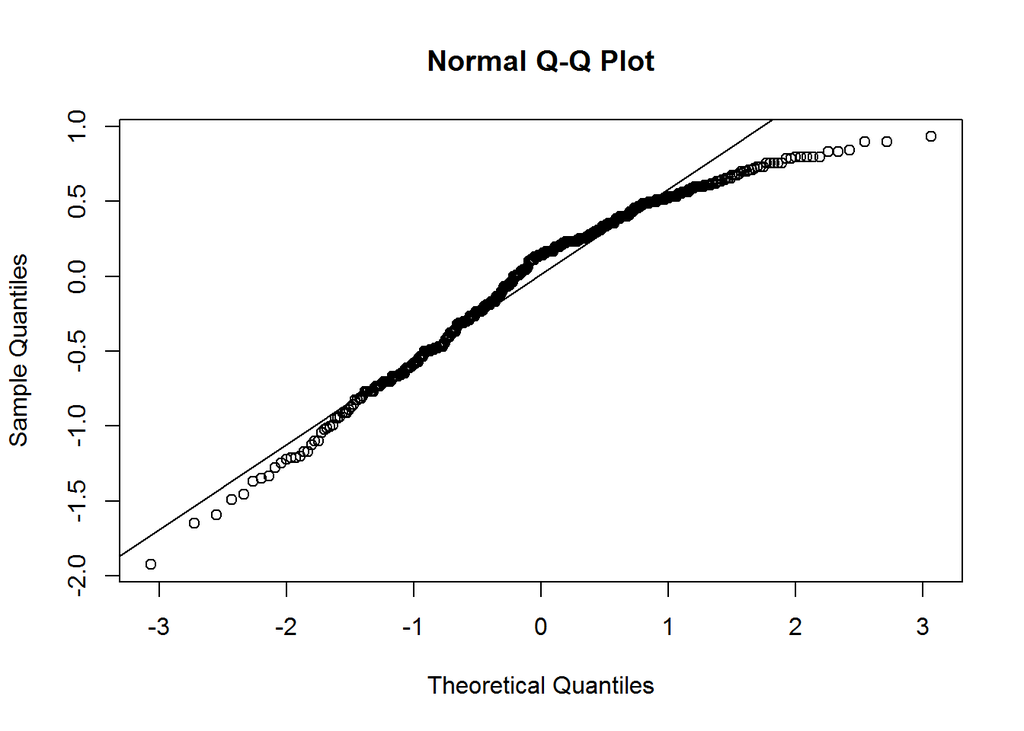

```r
qqnorm(m_bty$residuals)
qqline(m_bty$residuals)
```

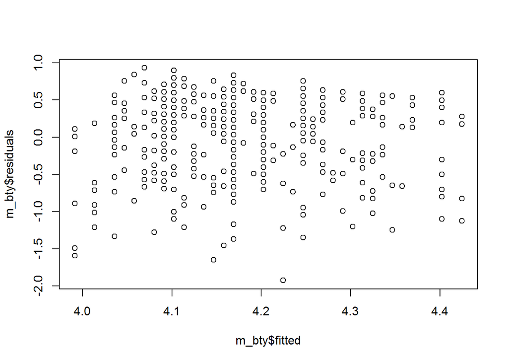

```r
#constant variability of residuals
plot(m_bty$residuals ~ m_bty$fitted)
```

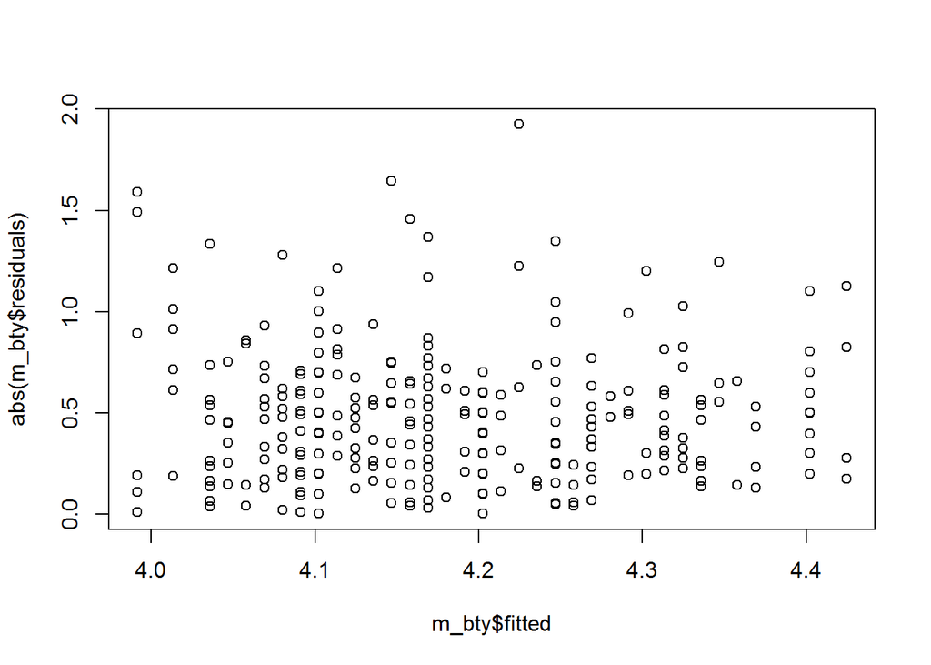

```r
plot(abs(m_bty$residuals) ~ m_bty$fitted)
```

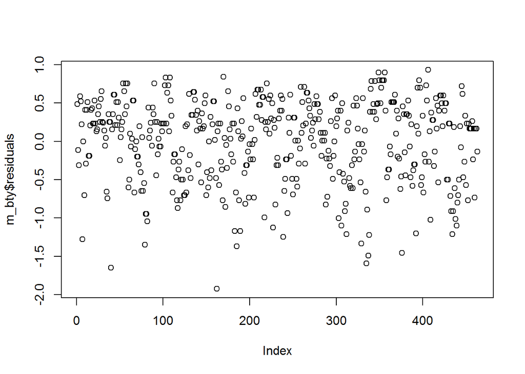

```r
#independent residuals
plot(m_bty$residuals)
```

## Multiple linear regression

The data set contains several variables on the beauty score of the professor: individual ratings from each of the six students who were asked to score the physical appearance of the professors and the average of these six scores. Let’s take a look at the relationship between one of these scores and the average beauty score.

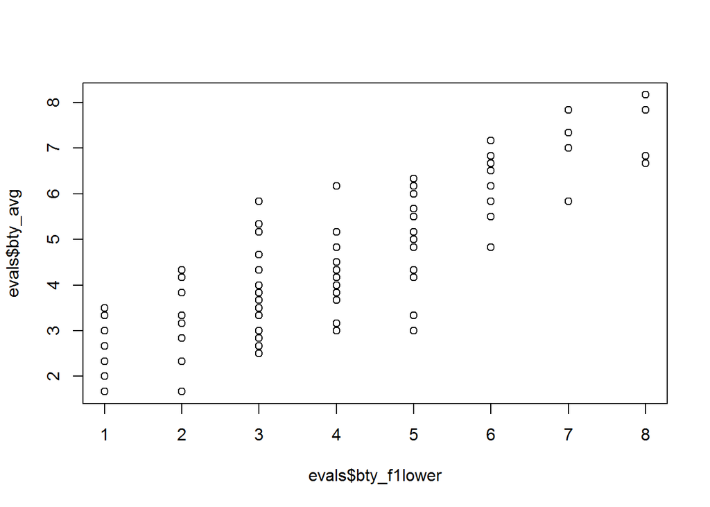

```r
library(corrplot)

plot(evals$bty_avg ~ evals$bty_f1lower)
```

```r
cor(evals$bty_avg, evals$bty_f1lower)
```

```
## [1] 0.8439112
```

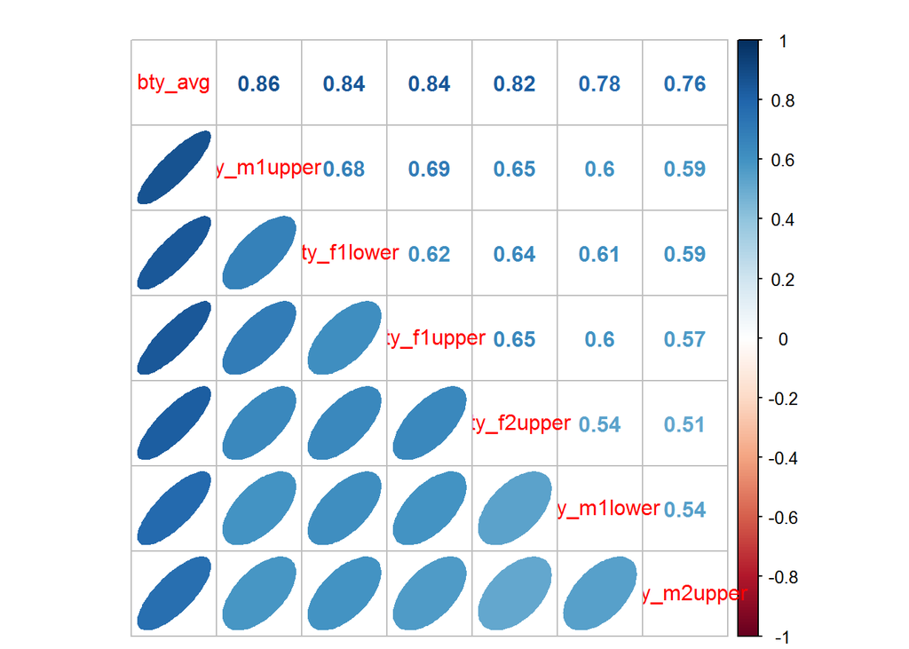

```r
#plot(evals[,13:19])


#order by FCP
corrplot.mixed(cor(evals[,13:19]), lower = "ellipse", upper = "number", order = "FPC")
```

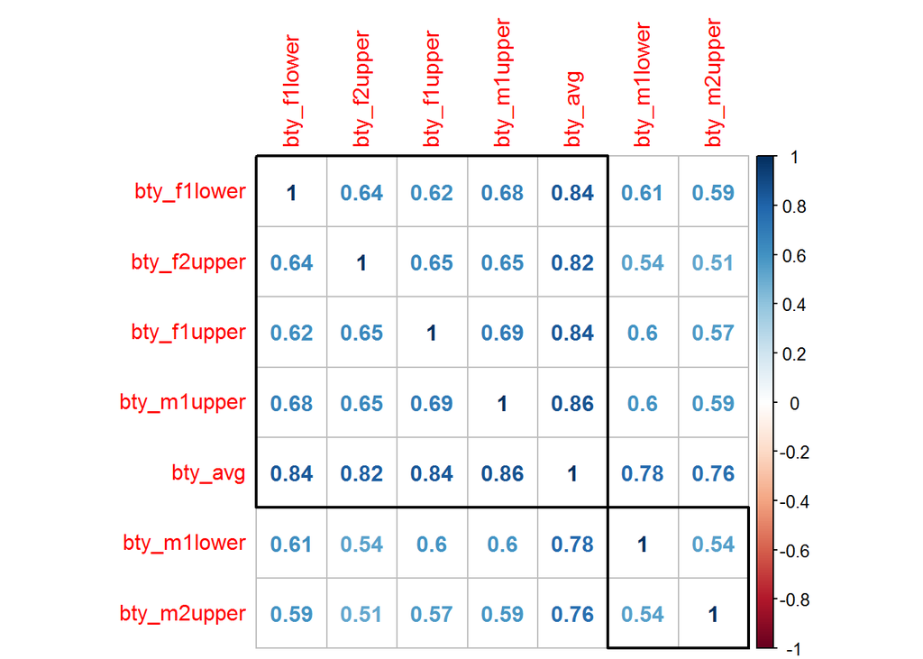

```r
#order by herarhical clustering and then show groups
corrplot(cor(evals[,13:19]), method = "number", order = "hclust", addrect = 2)
```

These variables are collinear (correlated), and adding more than one of these variables to the model would not add much value to the model. In this application and with these highly-correlated predictors, it is reasonable to use the average beauty score as the single representative of these variables.

In order to see if beauty is still a significant predictor of professor score after we’ve accounted for the gender of the professor, we can add the gender term into the model.

```r
m_bty_gen <- lm(score ~ bty_avg + gender, data = evals)
summary(m_bty_gen)
```

```
##
## Call:
## lm(formula = score ~ bty_avg + gender, data = evals)
##
## Residuals:
##     Min      1Q  Median      3Q     Max
## -1.8305 -0.3625  0.1055  0.4213  0.9314
##
## Coefficients:
##             Estimate Std. Error t value Pr(>|t|)
## (Intercept)  3.74734    0.08466  44.266  < 2e-16 ***
## bty_avg      0.07416    0.01625   4.563 6.48e-06 ***
## gendermale   0.17239    0.05022   3.433 0.000652 ***
## ---
## Signif. codes:  0 '***' 0.001 '**' 0.01 '*' 0.05 '.' 0.1 ' ' 1
##
## Residual standard error: 0.5287 on 460 degrees of freedom
## Multiple R-squared:  0.05912,    Adjusted R-squared:  0.05503
## F-statistic: 14.45 on 2 and 460 DF,  p-value: 8.177e-07
```

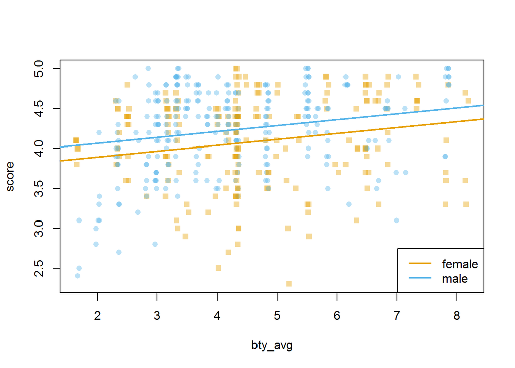

```r
multiLines(m_bty_gen)
```

Create a new model called m_bty_rank with gender removed and rank added in.

```r
m_bty_rank <- lm(score ~ bty_avg + rank, data = evals)
summary(m_bty_rank)
```

```
##
## Call:
## lm(formula = score ~ bty_avg + rank, data = evals)
##
## Residuals:
##     Min      1Q  Median      3Q     Max
## -1.8713 -0.3642  0.1489  0.4103  0.9525
##
## Coefficients:
##                  Estimate Std. Error t value Pr(>|t|)
## (Intercept)       3.98155    0.09078  43.860  < 2e-16 ***
## bty_avg           0.06783    0.01655   4.098 4.92e-05 ***
## ranktenure track -0.16070    0.07395  -2.173   0.0303 *
## ranktenured      -0.12623    0.06266  -2.014   0.0445 *
## ---
## Signif. codes:  0 '***' 0.001 '**' 0.01 '*' 0.05 '.' 0.1 ' ' 1
##
## Residual standard error: 0.5328 on 459 degrees of freedom
## Multiple R-squared:  0.04652,    Adjusted R-squared:  0.04029
## F-statistic: 7.465 on 3 and 459 DF,  p-value: 6.88e-05
```

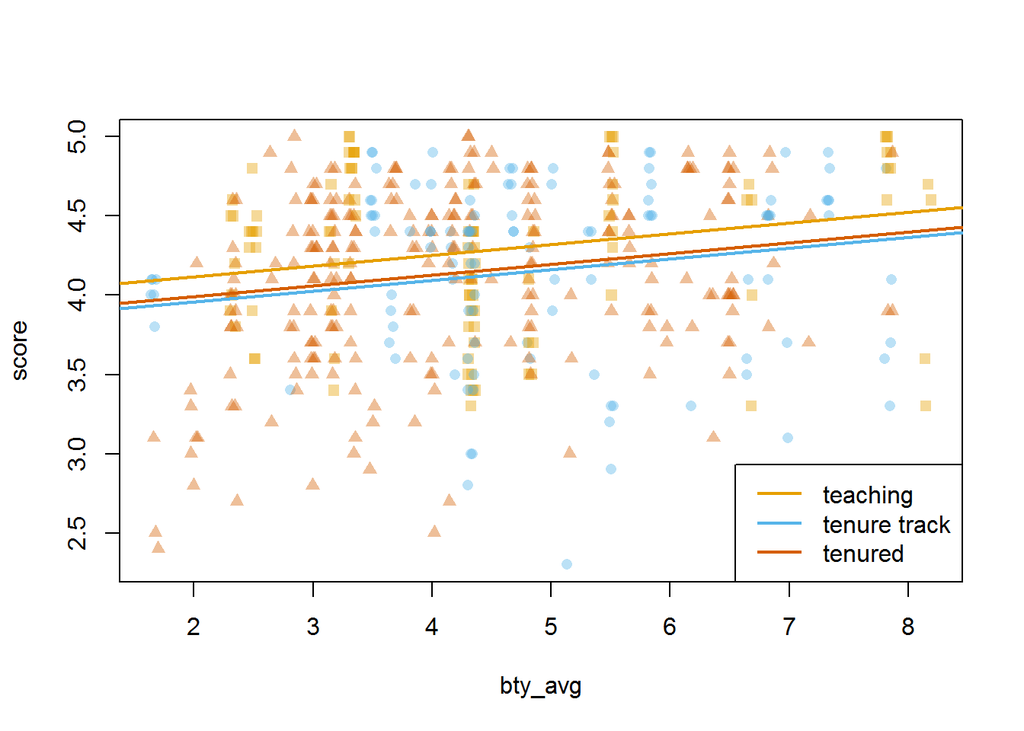

```r
multiLines(m_bty_rank)
```

# The search for the best model

```r
m_full <- lm(score ~ rank + ethnicity + gender + language + age + cls_perc_eval
             + cls_students + cls_level + cls_profs + cls_credits + bty_avg, data = evals)
summary(m_full)
```

```
##
## Call:
## lm(formula = score ~ rank + ethnicity + gender + language + age +
##     cls_perc_eval + cls_students + cls_level + cls_profs + cls_credits +
##     bty_avg, data = evals)
##
## Residuals:
##      Min       1Q   Median       3Q      Max
## -1.84482 -0.31367  0.08559  0.35732  1.10105
##
## Coefficients:
##                         Estimate Std. Error t value Pr(>|t|)
## (Intercept)            3.5305036  0.2408200  14.660  < 2e-16 ***
## ranktenure track      -0.1070121  0.0820250  -1.305 0.192687
## ranktenured           -0.0450371  0.0652185  -0.691 0.490199
## ethnicitynot minority  0.1869649  0.0775329   2.411 0.016290 *
## gendermale             0.1786166  0.0515346   3.466 0.000579 ***
## languagenon-english   -0.1268254  0.1080358  -1.174 0.241048
## age                   -0.0066498  0.0030830  -2.157 0.031542 *
## cls_perc_eval          0.0056996  0.0015514   3.674 0.000268 ***
## cls_students           0.0004455  0.0003585   1.243 0.214596
## cls_levelupper         0.0187105  0.0555833   0.337 0.736560
## cls_profssingle       -0.0085751  0.0513527  -0.167 0.867458
## cls_creditsone credit  0.5087427  0.1170130   4.348  1.7e-05 ***
## bty_avg                0.0612651  0.0166755   3.674 0.000268 ***
## ---
## Signif. codes:  0 '***' 0.001 '**' 0.01 '*' 0.05 '.' 0.1 ' ' 1
##
## Residual standard error: 0.504 on 450 degrees of freedom
## Multiple R-squared:  0.1635, Adjusted R-squared:  0.1412
## F-statistic: 7.331 on 12 and 450 DF,  p-value: 2.406e-12
```

```r
m_full <- lm(score ~ rank + ethnicity + gender + language + age + cls_perc_eval
             + cls_students + cls_level + cls_profs + cls_credits, data = evals)
summary(m_full)
```

```
##
## Call:
## lm(formula = score ~ rank + ethnicity + gender + language + age +
##     cls_perc_eval + cls_students + cls_level + cls_profs + cls_credits,
##     data = evals)
##
## Residuals:
##      Min       1Q   Median       3Q      Max
## -1.83161 -0.32725  0.06013  0.34886  1.08157
##
## Coefficients:
##                         Estimate Std. Error t value Pr(>|t|)
## (Intercept)            3.8540143  0.2272286  16.961  < 2e-16 ***
## ranktenure track      -0.1182861  0.0830956  -1.423 0.155284
## ranktenured           -0.0698571  0.0657603  -1.062 0.288669
## ethnicitynot minority  0.1831307  0.0785927   2.330 0.020240 *
## gendermale             0.1707584  0.0521988   3.271 0.001153 **
## languagenon-english   -0.1197846  0.1095053  -1.094 0.274595
## age                   -0.0090192  0.0030563  -2.951 0.003332 **
## cls_perc_eval          0.0067109  0.0015478   4.336 1.79e-05 ***
## cls_students           0.0006647  0.0003583   1.855 0.064222 .
## cls_levelupper         0.0160725  0.0563435   0.285 0.775576
## cls_profssingle       -0.0007591  0.0520147  -0.015 0.988363
## cls_creditsone credit  0.4588161  0.1178206   3.894 0.000113 ***
## ---
## Signif. codes:  0 '***' 0.001 '**' 0.01 '*' 0.05 '.' 0.1 ' ' 1
##
## Residual standard error: 0.5109 on 451 degrees of freedom
## Multiple R-squared:  0.1384, Adjusted R-squared:  0.1174
## F-statistic: 6.588 on 11 and 451 DF,  p-value: 3.11e-10
```

```r
m_full <- lm(score ~ rank + ethnicity + gender + language + age + cls_perc_eval
             + cls_students + cls_level + cls_credits + bty_avg, data = evals)
summary(m_full)
```

```
##
## Call:
## lm(formula = score ~ rank + ethnicity + gender + language + age +
##     cls_perc_eval + cls_students + cls_level + cls_credits +
##     bty_avg, data = evals)
##
## Residuals:
##      Min       1Q   Median       3Q      Max
## -1.85048 -0.31394  0.08052  0.35956  1.10356
##
## Coefficients:
##                         Estimate Std. Error t value Pr(>|t|)
## (Intercept)            3.5286297  0.2402990  14.684  < 2e-16 ***
## ranktenure track      -0.1073638  0.0819096  -1.311 0.190606
## ranktenured           -0.0453744  0.0651169  -0.697 0.486278
## ethnicitynot minority  0.1893718  0.0760992   2.488 0.013189 *
## gendermale             0.1780270  0.0513581   3.466 0.000578 ***
## languagenon-english   -0.1265737  0.1079088  -1.173 0.241427
## age                   -0.0066619  0.0030788  -2.164 0.031006 *
## cls_perc_eval          0.0056790  0.0015448   3.676 0.000265 ***
## cls_students           0.0004493  0.0003573   1.257 0.209319
## cls_levelupper         0.0183743  0.0554870   0.331 0.740687
## cls_creditsone credit  0.5109162  0.1161614   4.398 1.36e-05 ***
## bty_avg                0.0611497  0.0166432   3.674 0.000267 ***
## ---
## Signif. codes:  0 '***' 0.001 '**' 0.01 '*' 0.05 '.' 0.1 ' ' 1
##
## Residual standard error: 0.5035 on 451 degrees of freedom
## Multiple R-squared:  0.1635, Adjusted R-squared:  0.1431
## F-statistic: 8.012 on 11 and 451 DF,  p-value: 8.303e-13
```

```r
m_full <- lm(score ~ rank + ethnicity + gender + language + age + cls_perc_eval
             + cls_level + cls_profs + cls_credits + bty_avg, data = evals)
summary(m_full)
```

```
##
## Call:
## lm(formula = score ~ rank + ethnicity + gender + language + age +
##     cls_perc_eval + cls_level + cls_profs + cls_credits + bty_avg,
##     data = evals)
##
## Residuals:
##     Min      1Q  Median      3Q     Max
## -1.8484 -0.3141  0.0774  0.3554  1.0628
##
## Coefficients:
##                        Estimate Std. Error t value Pr(>|t|)
## (Intercept)            3.595980   0.235128  15.294  < 2e-16 ***
## ranktenure track      -0.102325   0.081988  -1.248 0.212658
## ranktenured           -0.031216   0.064302  -0.485 0.627592
## ethnicitynot minority  0.190068   0.077539   2.451 0.014615 *
## gendermale             0.184118   0.051375   3.584 0.000376 ***
## languagenon-english   -0.131693   0.108030  -1.219 0.223466
## age                   -0.006840   0.003081  -2.220 0.026908 *
## cls_perc_eval          0.005045   0.001460   3.455 0.000602 ***
## cls_levelupper         0.003028   0.054165   0.056 0.955445
## cls_profssingle       -0.012618   0.051280  -0.246 0.805748
## cls_creditsone credit  0.497540   0.116736   4.262 2.47e-05 ***
## bty_avg                0.064715   0.016453   3.933 9.69e-05 ***
## ---
## Signif. codes:  0 '***' 0.001 '**' 0.01 '*' 0.05 '.' 0.1 ' ' 1
##
## Residual standard error: 0.5043 on 451 degrees of freedom
## Multiple R-squared:  0.1607, Adjusted R-squared:  0.1402
## F-statistic: 7.847 on 11 and 451 DF,  p-value: 1.643e-12
```

```r
m_full <- lm(score ~ ethnicity + gender + language + age + cls_perc_eval
             + cls_students + cls_level + cls_profs + cls_credits + bty_avg, data = evals)
summary(m_full)
```

```
##
## Call:
## lm(formula = score ~ ethnicity + gender + language + age + cls_perc_eval +
##     cls_students + cls_level + cls_profs + cls_credits + bty_avg,
##     data = evals)
##
## Residuals:
##      Min       1Q   Median       3Q      Max
## -1.89156 -0.30604  0.09081  0.37048  1.09228
##
## Coefficients:
##                         Estimate Std. Error t value Pr(>|t|)
## (Intercept)            3.3828570  0.2117452  15.976  < 2e-16 ***
## ethnicitynot minority  0.1991208  0.0768405   2.591 0.009869 **
## gendermale             0.1782724  0.0506325   3.521 0.000474 ***
## languagenon-english   -0.1556389  0.1050930  -1.481 0.139313
## age                   -0.0049143  0.0026218  -1.874 0.061525 .
## cls_perc_eval          0.0057713  0.0015489   3.726 0.000219 ***
## cls_students           0.0004226  0.0003527   1.198 0.231450
## cls_levelupper         0.0144196  0.0553118   0.261 0.794445
## cls_profssingle       -0.0103198  0.0513079  -0.201 0.840683
## cls_creditsone credit  0.5292245  0.1119263   4.728 3.03e-06 ***
## bty_avg                0.0621166  0.0165775   3.747 0.000202 ***
## ---
## Signif. codes:  0 '***' 0.001 '**' 0.01 '*' 0.05 '.' 0.1 ' ' 1
##
## Residual standard error: 0.5038 on 452 degrees of freedom
## Multiple R-squared:  0.1604, Adjusted R-squared:  0.1418
## F-statistic: 8.632 on 10 and 452 DF,  p-value: 5.779e-13
```